# HW3

## Part1

### Task 1: read in the data

```python
import pandas as pd
import matplotlib.pyplot as plt
```

```python
ST_math = pd.read_csv("Description/student-mat.csv",sep = ";")
```

```python
ST_math.head()
```

|  | school | sex | age | address | famsize | Pstatus | Medu | Fedu | Mjob | Fjob | ... | famrel | freetime | goout | Dalc | Walc | health | absences | G1 | G2 | G3 |
| --- | --- | --- | --- | --- | --- | --- | --- | --- | --- | --- | --- | --- | --- | --- | --- | --- | --- | --- | --- | --- | --- |
| 0 | GP | F | 18 | U | GT3 | A | 4 | 4 | at_home | teacher | ... | 4 | 3 | 4 | 1 | 1 | 3 | 6 | 5 | 6 | 6 |
| 1 | GP | F | 17 | U | GT3 | T | 1 | 1 | at_home | other | ... | 5 | 3 | 3 | 1 | 1 | 3 | 4 | 5 | 5 | 6 |
| 2 | GP | F | 15 | U | LE3 | T | 1 | 1 | at_home | other | ... | 4 | 3 | 2 | 2 | 3 | 3 | 10 | 7 | 8 | 10 |
| 3 | GP | F | 15 | U | GT3 | T | 4 | 2 | health | services | ... | 3 | 2 | 2 | 1 | 1 | 5 | 2 | 15 | 14 | 15 |
| 4 | GP | F | 16 | U | GT3 | T | 3 | 3 | other | other | ... | 4 | 3 | 2 | 1 | 2 | 5 | 4 | 6 | 10 | 10 |

5 rows × 33 columns

```python
CT = lambda x: x.astype("category")
ST_math[['school', 'sex', 'address', 'famsize', 'Pstatus', 'Medu', 'Fedu',
       'Mjob', 'Fjob','guardian','failures', 'schoolsup', 'famsup', 'paid', 'activities', 'nursery',
       'higher', 'internet', 'romantic', 'famrel', 'freetime', 'goout', 'Dalc',
       'Walc', 'health', 'absences']] = ST_math[['school', 'sex', 'address', 'famsize', 'Pstatus', 'Medu', 'Fedu',
       'Mjob', 'Fjob','guardian','failures', 'schoolsup', 'famsup', 'paid', 'activities', 'nursery',
       'higher', 'internet', 'romantic', 'famrel', 'freetime', 'goout', 'Dalc',
       'Walc', 'health', 'absences']].apply(CT)
ST_math.G1
```

```
0       5
1       5
2       7
3      15
4       6
       ..
390     9
391    14
392    10
393    11
394     8
Name: G1, Length: 395, dtype: int64
```

### Task 2: Summarize the data

**Categorical variables**

- Create a one-way contingency table, a two-way contingency table, and a three-way contingency table

```python
oneway = ST_math.school.value_counts(dropna = False)
oneway
```

```
GP    349
MS     46
Name: school, dtype: int64
```

*There are 349 students studying in GP*

```python
twoway = pd.crosstab(ST_math.sex,ST_math.guardian,rownames = ["SEX"],colnames = ["GUARDIAN"])
twoway
```

| GUARDIAN SEX | father | mother | other |
| --- | --- | --- | --- |
| F | 43 | 145 | 20 |
| M | 47 | 128 | 12 |

*There are 43 female students whose guardian is fatehr*

```python
threeway = pd.crosstab(index = [ST_math.sex,ST_math.guardian],columns = ST_math.internet, margins = True,)
threeway
```

| sex | internet guardian | no | yes | All |
| --- | --- | --- | --- | --- |
| F | father | 8 | 35 | 43 |
|  | mother | 26 | 119 | 145 |
|  | other | 4 | 16 | 20 |
| M | father | 4 | 43 | 47 |
|  | mother | 21 | 107 | 128 |
|  | other | 3 | 9 | 12 |
| All |  | 66 | 329 | 395 |

*8 female students whose guardian is father do not have internet*

- Create a conditional two-way table. That is, condition on one variable’s setting and create a two-way table. Do this using two different methods

```python
threeway = pd.crosstab(index = [ST_math.sex,ST_math.guardian],columns = ST_math.internet, margins = True,)
threeway.loc["M",:]
```

| internet guardian | no | yes | All |
| --- | --- | --- | --- |
| father | 4 | 43 | 47 |
| mother | 21 | 107 | 128 |
| other | 3 | 9 | 12 |

- Create a stacked bar graph and a side-by-side bar graph. Give relevant x and y labels, and a title for the plots

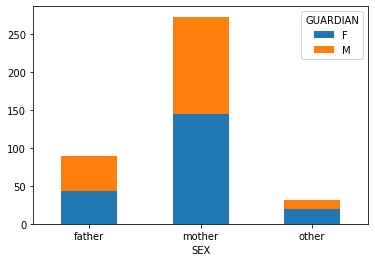

```python
twoway = pd.crosstab(ST_math.guardian,ST_math.sex,rownames = ["SEX"],colnames = ["GUARDIAN"])
twoway.plot.bar(stacked = True)
plt.xticks(rotation = 0)
plt.show()
```

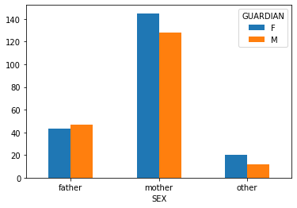

```python
twoway = pd.crosstab(ST_math.guardian,ST_math.sex,rownames = ["SEX"],colnames = ["GUARDIAN"])
twoway.plot.bar()
plt.xticks(rotation = 0)
plt.show()
```

**Numeric variables**

- Find measures of center and spread for three of these variables

```python
ST_math.loc[:,["G1","G2","G3"]].mean()
```

```
G1    10.908861
G2    10.713924
G3    10.415190
dtype: float64
```

```python
ST_math.loc[:,["G1","G2","G3"]].median()
```

```
G1    11.0
G2    11.0
G3    11.0
dtype: float64
```

```python
ST_math.loc[:,["G1","G2","G3"]].std()
```

```
G1    3.319195
G2    3.761505
G3    4.581443
dtype: float64
```

- Find measures of center and spread across a single grouping variable for three of these variables

```python
ST_math.groupby("sex").mean().loc[:,["G1","G2","G3"]]
```

| sex | G1 | G2 | G3 |
| --- | --- | --- | --- |
| F | 10.620192 | 10.389423 | 9.966346 |
| M | 11.229947 | 11.074866 | 10.914439 |

```python
ST_math.groupby("sex").median().loc[:,["G1","G2","G3"]]
```

| sex | G1 | G2 | G3 |
| --- | --- | --- | --- |
| F | 10.0 | 10.0 | 10.0 |
| M | 11.0 | 11.0 | 11.0 |

```python
ST_math.groupby("sex").std().loc[:,["G1","G2","G3"]]
```

| sex | G1 | G2 | G3 |
| --- | --- | --- | --- |
| F | 3.232530 | 3.641851 | 4.622338 |
| M | 3.392839 | 3.868088 | 4.495297 |

- Find measures of center and spread across two grouping variables for three of these variables

```python
ST_math.groupby(["sex","guardian"]).mean().loc[:,["G1","G2","G3"]]
```

| sex | guardian | G1 | G2 | G3 |
| --- | --- | --- | --- | --- |
| F | father | 11.023256 | 11.046512 | 10.581395 |
|  | mother | 10.517241 | 10.365517 | 10.041379 |
|  | other | 10.500000 | 9.150000 | 8.100000 |
| M | father | 11.191489 | 11.255319 | 10.787234 |
|  | mother | 11.296875 | 11.031250 | 10.984375 |
|  | other | 10.666667 | 10.833333 | 10.666667 |

```python
ST_math.groupby(["sex","guardian"]).median().loc[:,["G1","G2","G3"]]
```

| sex | guardian | G1 | G2 | G3 |
| --- | --- | --- | --- | --- |
| F | father | 10.0 | 11.0 | 11.0 |
|  | mother | 10.0 | 10.0 | 10.0 |
|  | other | 10.0 | 9.5 | 9.5 |
| M | father | 11.0 | 11.0 | 11.0 |
|  | mother | 11.0 | 11.5 | 11.0 |
|  | other | 9.5 | 9.5 | 9.5 |

```python
ST_math.groupby(["sex","guardian"]).std().loc[:,["G1","G2","G3"]]
```

| sex | guardian | G1 | G2 | G3 |
| --- | --- | --- | --- | --- |
| F | father | 3.362881 | 3.651180 | 4.671252 |
|  | mother | 3.216933 | 3.609043 | 4.504436 |
|  | other | 3.153945 | 3.703128 | 5.118594 |
| M | father | 3.069048 | 3.144824 | 4.313458 |
|  | mother | 3.521273 | 4.152482 | 4.666828 |
|  | other | 3.420083 | 3.511885 | 3.498918 |

- Create a correlation matrix between all of the numeric variables

```python
ST_math.columns
```

```
Index(['school', 'sex', 'age', 'address', 'famsize', 'Pstatus', 'Medu', 'Fedu',
       'Mjob', 'Fjob', 'reason', 'guardian', 'traveltime', 'studytime',
       'failures', 'schoolsup', 'famsup', 'paid', 'activities', 'nursery',
       'higher', 'internet', 'romantic', 'famrel', 'freetime', 'goout', 'Dalc',
       'Walc', 'health', 'absences', 'G1', 'G2', 'G3'],
      dtype='object')
```

```python
ST_math[["age","traveltime","studytime","G1","G2","G3"]].corr()
```

[output not shown]

- Create a histogram, kernel density plot, and boxplot for two of the numeric variables across one of the categorical variables

**HISTOGRAM**

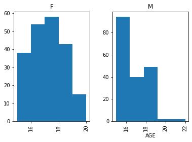

```python
ST_math.age.hist(bins = 5, by = ST_math.sex)
plt.xlabel("AGE")
```

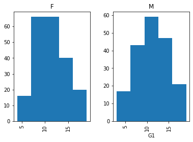

```python
ST_math.G1.hist(bins = 5, by = ST_math.sex)
plt.xlabel("G1")
```

**KERNEL DENSITY**

```python
age_F = ST_math.loc[ST_math.sex == "F","age"]
age_M = ST_math.loc[ST_math.sex == "M","age"]
age_T = pd.DataFrame([pd.Series(age_F),pd.Series(age_M)]).transpose()
```

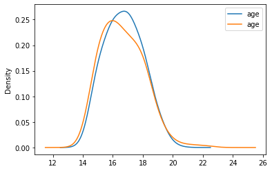

```python
D1 = age_T.age.plot.density(bw_method = 0.5)
```

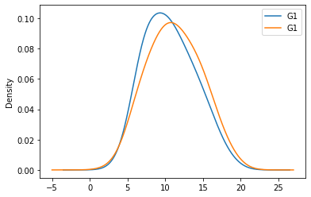

```python
G1_F = ST_math.loc[ST_math.sex == "F","G1"]
G1_M = ST_math.loc[ST_math.sex == "M","G1"]
G1_T = pd.DataFrame([pd.Series(G1_F),pd.Series(G1_M)]).transpose()
D2 = G1_T.G1.plot.density(bw_method = 0.5)
```

**BOXPLOT**

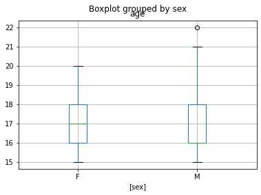

```python
ST_math.boxplot(column = ["age"], by = ["sex"])
```

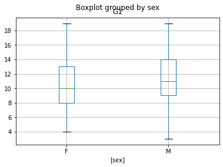

```python
ST_math.boxplot(column = ["G1"], by = ["sex"])
```

- Create two scatterplots relating G3 to other numeric variables (G3 on the y-axis). Color the points by a categorical variable in each. Add appropriate labels and titles.

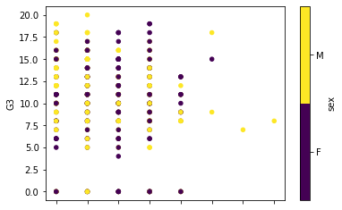

```python
ST_math.plot.scatter(x = "age", y = "G3", c = "sex",cmap = "viridis")
plt.xlabel("AGE")
```

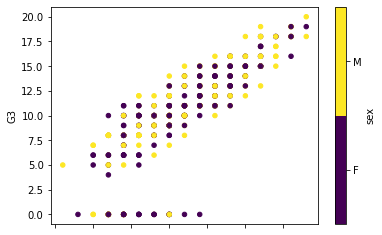

```python
ST_math.plot.scatter(x = "G1", y = "G3", c = "sex",cmap = "viridis")
plt.xlabel("G1")
```

## Part2

### Task 1: Read in the data

```python
Data = pd.read_excel("Description/WorldDevelopmentIndicators.xlsx", sheet_name = "Data")
Data.head()
```

|  | Country Name | Country Code | Indicator Name | Indicator Code | Year | Value |
| --- | --- | --- | --- | --- | --- | --- |
| 0 | Arab World | ARB | Access to clean fuels and technologies for coo... | EG.CFT.ACCS.ZS | 2000 | 73.702495 |
| 1 | Arab World | ARB | Access to clean fuels and technologies for coo... | EG.CFT.ACCS.ZS | 2001 | 74.944860 |
| 2 | Arab World | ARB | Access to clean fuels and technologies for coo... | EG.CFT.ACCS.ZS | 2002 | 76.258066 |
| 3 | Arab World | ARB | Access to clean fuels and technologies for coo... | EG.CFT.ACCS.ZS | 2003 | 77.120464 |
| 4 | Arab World | ARB | Access to clean fuels and technologies for coo... | EG.CFT.ACCS.ZS | 2004 | 78.094440 |

### Task 2: Summarize the data

```python
CT = lambda x: x.astype("category")
Data[["Country Name","Country Code","Indicator Code"]] = Data[["Country Name","Country Code","Indicator Code"]].apply(CT)
```

```python
import plotnine
from plotnine import ggplot, aes
```

```python
DataLAC = Data[Data["Country Code"] == "LAC"]
DataLAC = DataLAC[Data["Indicator Code"] == "EG.CFT.ACCS.ZS"]
DataLDC = Data[Data["Country Code"] == "LDC"]
DataLDC = DataLDC[Data["Indicator Code"] == "EG.CFT.ACCS.ZS"]
DataNAC = Data[Data["Country Code"] == "NAC"]
DataNAC = DataNAC[Data["Indicator Code"] == "EG.CFT.ACCS.ZS"]
```

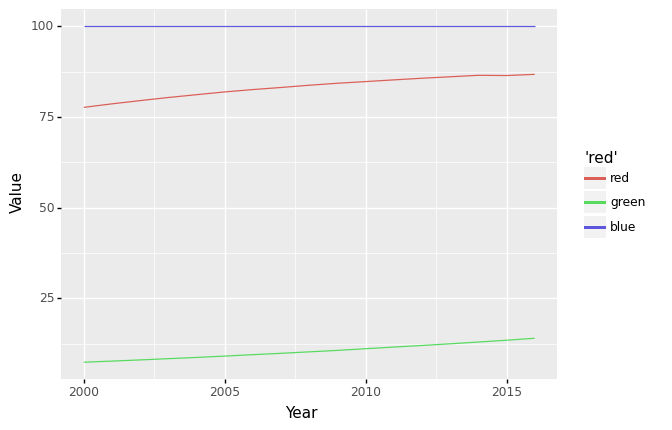

```python
 (ggplot(data = DataLAC, mapping = aes(x = "Year", y = "Value"))+
 plotnine.geom_line(data = DataLAC, mapping = aes(x = "Year", y = "Value", color = "'red'")) +
 plotnine.geom_line(data = DataLDC, mapping = aes(x = "Year", y = "Value", color = "'green'"))+
 plotnine.geom_line(data = DataNAC, mapping = aes(x = "Year", y = "Value", color = "'blue'")))
```

```python
DataLIC = Data[Data["Country Code"] == "LIC"]
DataLIC = DataLIC[Data["Indicator Code"] == "SE.ENR.PRIM.FM.ZS"]
DataLMC = Data[Data["Country Code"] == "LMC"]
DataLMC = DataLMC[Data["Indicator Code"] == "SE.ENR.PRIM.FM.ZS"]
DataMIC = Data[Data["Country Code"] == "MIC"]
DataMIC = DataMIC[Data["Indicator Code"] == "SE.ENR.PRIM.FM.ZS"]
DataHIC = Data[Data["Country Code"] == "HIC"]
DataHIC = DataHIC[Data["Indicator Code"] == "SE.ENR.PRIM.FM.ZS"]
DataT = Data[Data["Indicator Code"] == "SE.ENR.PRIM.FM.ZS"]
```

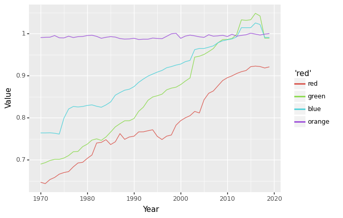

```python
 (ggplot(data = DataT, mapping = aes(x = "Year", y = "Value"))+
 plotnine.geom_line(data = DataLIC, mapping = aes(x = "Year", y = "Value", color = "'red'"))+
 plotnine.geom_line(data = DataLMC, mapping = aes(x = "Year", y = "Value", color = "'green'")) +
 plotnine.geom_line(data = DataMIC, mapping = aes(x = "Year", y = "Value", color = "'blue'"))+
 plotnine.geom_line(data = DataHIC, mapping = aes(x = "Year", y = "Value", color = "'orange'"))
 )
```